# Phy 481 Homework 12

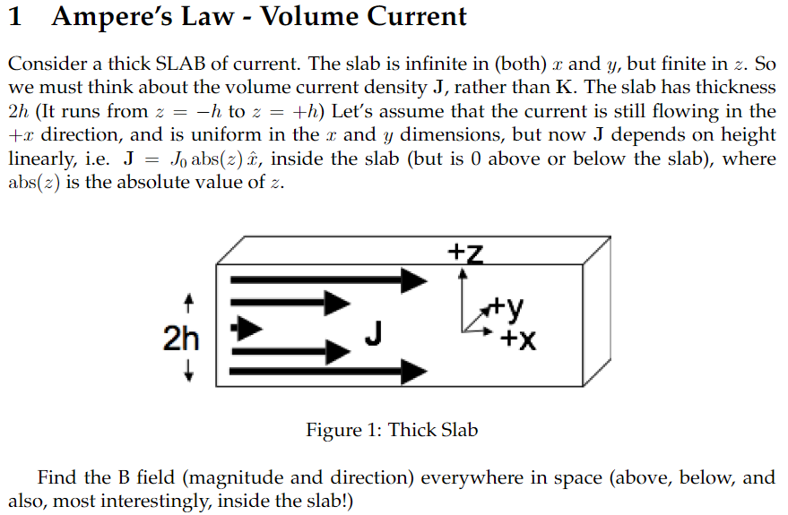

Symmetric about z-axis. Use an amperian loop

$$ \oint \vec B \cdot d\vec l = \mu_0 \int \vec J \cdot d\vec a $$

$\vec B$ is zero up and down. Use recangular loop of height $z$ and arbitrary length $L$.

$$ \oint \vec B \cdot d\vec l = \int_0^L B(z) dL -\int_{L}^0 B(z)dl = 2LB(z) \\ $$ Next the area of the loop $$ d\vec a = dy dz \hat x \\ \vec J(z) = J_0 \text{abs}(z)x \\ \int \vec J(z) \cdot d\vec a = \int_{-z}^z\int_{0}^L J_0 |z| dy dz = 2\int_0^z\int_{0}^L J_0 z dy dz \\ = 2J_0L \int_0^z z dz = \mu_0 J_0 L z^2 $$ Combine them together $$ 2LB(z) = \mu_0 J_0 L z^2 \\ B(z) = \frac{\mu_0 J_0 z^2}{2} \\ \vec B(z) = \begin{cases} -B(z) \hat y & z\geq 0 \\ B(z) \hat y & z < 0\end{cases} $$ Vector signs/directions are determined via right-hand-rule

For the field outside the slab: area integral stops at $z=\pm h$ since $\vec J(|z|>h)=0$.

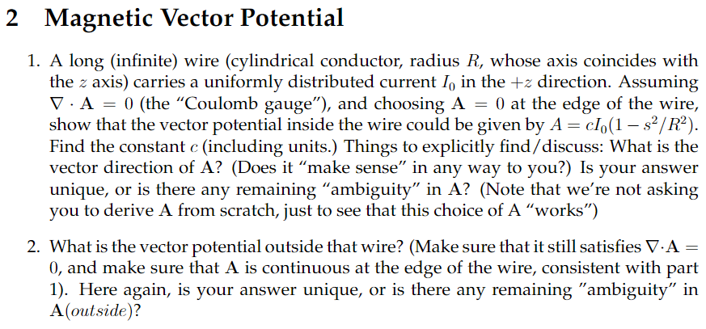

Properties of $\vec A$:  
$\vec B = \vec \nabla \times \vec A$  
$\nabla \cdot \vec A = 0$  
$\vec A(s=R)=0$

Since $\vec A$ points in the direction of current, we should also have $\vec A = A\hat z$

Check that $A$ can produce the uniform current $I_0$

$$ \vec \nabla \times \vec B = \mu_0 \vec J \\ \vec \nabla \times (\vec \nabla \times \vec A) = \vec \nabla (\vec \nabla \cdot \vec A) - \nabla^2\vec A \\ = 0-\nabla^2\vec A = \mu_0 \vec J \\ \vec J = \frac{I_0 \hat z}{\pi R^2} \\ \nabla^2\vec A = -\mu_0 \frac{I_0 \hat z}{\pi R^2} $$ Let's apply $\nabla^2$ to $\vec A=cI_0 \left(1 - \frac{s^2}{R^2}\right)\hat z$. I think
Since $\vec A$ is only in the $z$ direction and $\frac{\partial A}{\partial z} = \frac{\partial A}{\partial \phi} = 0$, this gives us

$$ \nabla^2 A*\hat z= \frac{1}{s} \frac{\partial}{\partial s} \left( s \frac{\partial A}{\partial s}\right)\hat z = -4c\frac{I_0}{R^2} \hat z \\ -4c\frac{I_0}{R^2} = -\mu_0 \frac{I_0}{\pi R^2} \\ c = \frac{\mu_0}{4\pi} $$

Using $\vec A = \frac{\mu_0 I_0}{4\pi} \left(1 - \frac{s^2}{R^2}\right) \hat z$, we have defined $\vec A$ so that it meets all the requirements listed above (coulomb gauge, correct magnetic field, etc)

```python
from sympy import *

s, r, I, c = symbols('s R I_0 c')

A = c*I*(1-s**2/r**2)
diff(s*diff(A, s), s)/s
```

$\displaystyle - \frac{4 I_{0} c}{R^{2}}$

There is still potential outside the wire even if there is no current. We'll find $\vec B$ and determine what $\vec \nabla \times \vec A$ must be

$$ \oint \vec B \cdot d\vec l = \mu_0 I \\ B = \frac{\mu_0 I_0}{2\pi s} = \vec \nabla \times \vec A \\ $$ From rhr we know $B$ is in the $\hat \phi$ direction.

Since $\vec A = A\hat z$, we can find the matching $\vec \nabla \times \vec A$ relatively easily

$$ \vec \nabla \times \vec A = 0\hat s + \left(\frac{\partial A_s}{\partial z} - \frac{\partial A_z}{\partial s} \right) \hat \phi + 0\hat z \\ = 0\hat \phi - \frac{\partial A}{\partial s} \hat \phi $$ This gives us $$ -\frac{\partial A}{\partial s} = B = \frac{\mu_0 I_0}{2\pi s} \\ A = - \int B ds = -\frac{\mu_0 I_0}{2\pi} \log(s) + c $$ To have $A(s=R)=0$, we use $c = \frac{\mu_0 I_0}{2\pi} \log(R)$

$$ \vec A = \frac{\mu_0 I_0}{2\pi}\left(\log(R)- \log(s)\right) \hat z $$ So $A_{s\rightarrow \infty}= -\infty$? I'm sure that's not an issue. This has zero divergence and matches the boundary condition.

```python
mu0, pi = symbols('mu_0 pi')

-integrate(mu0*I/(2*pi*s), s)
```

$\displaystyle - \frac{I_{0} \mu_{0} \log{\left(s \right)}}{2 \pi}$

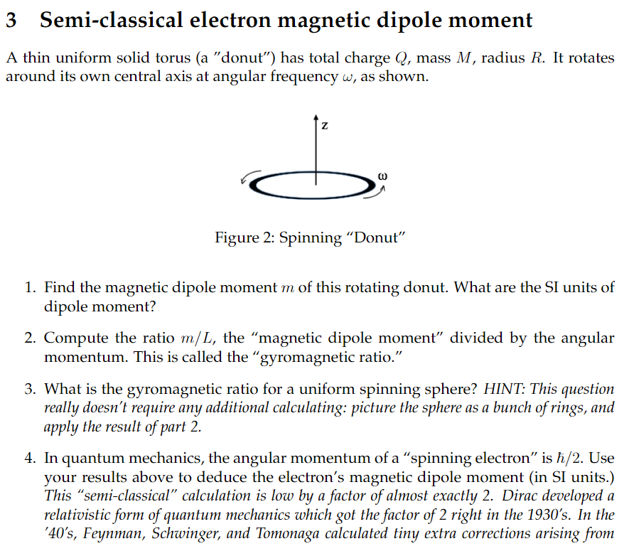

Magnetic dipole moment for ring

$$ \vec m = Ia \hat n \\ I = \frac{\omega Q}{2\pi} \\ a = \pi R^2 \hat n = \hat z \\ \vec m = \frac{\omega Q}{2\pi}\pi R^2\hat z \\= \frac{1}{2}\omega Q R^2 \hat z \\ $$ SI units are amps*meter^2 = $\frac{Cm^2}{s}$

Ratio  
Angular momentum $L = I\omega$

$$ L = MR^2 \omega \\ m/L = \frac{\frac{\omega Q R^2}{2}}{MR^2 \omega} = \frac{Q}{2M} $$

Sphere  
Since our previous result doesn't depend on radius, any cylindrically/axial symmetric mass/charge distribution has the same formula $\frac{Q}{2M}$

Electron magnetic moment

```python
from scipy.constants import hbar, electron_mass, elementary_charge

m = elementary_charge*hbar/(electron_mass*4)
m
```

```
4.637005039181082e-24
```

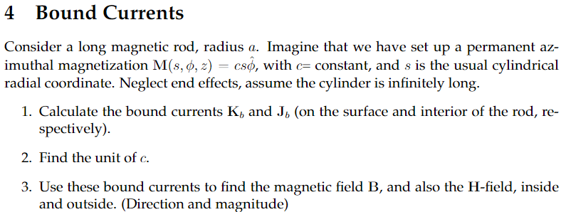

Permanent azimuthal magnetization: current is perpendicular, so it will point in the $z$ direction

$$ \vec M = cs \hat \phi = M\hat \phi \\ M = cs \\ J_b = \vec \nabla \times \vec M \\ = 0+0+ \frac{\partial}{\partial s}(sM) \frac{1}{s}\hat z\\ = 2c \hat z\\ K_b = \vec M \times \hat n \\ = cs \hat \phi \times \hat s = -cs \hat z \\ $$ At $s=a$ $$ K_b = -ca \hat z $$

```python
M = c*s
diff(s*M, s)/s
```

$\displaystyle 2 c$

Since $[K_b] = \frac{A}{m}$, we have

$$ \frac{A}{m} = [c][a] = [c]m \\ [c] = \frac{A}{m^2} $$

Inside rod: No contribution from $K_b$

$$ \oint \vec B \cdot d\vec l = \mu_0 \int \vec J \cdot d\vec a \\ 2\pi s B = c*\mu_0 2\pi s^2 \\ B = c\mu_0 s\\ \vec B = c\mu_0 s \hat \phi \\ $$

Outside rod: add in $K_b$ and find total current

$$ I = c 2\pi a^2 + \int K_b \cdot d\vec l \\ = c 2\pi a^2 - ca(2\pi a) = 0 $$ No net current means no magnetic field.

$H$: Only internal

$$ \vec H = \frac{\vec B}{\mu_0} - \vec M = \left(cs-cs \right)\hat \phi = 0 $$ Actually, no $H$ whatsoever.